# L’IMMOBILIER DANS LA COMMUNE D’ANTONY

Rapport confidentiel n°1

Author

FATOUMATA DIALLO

Published

April 10, 2026

## INTRODUCTION

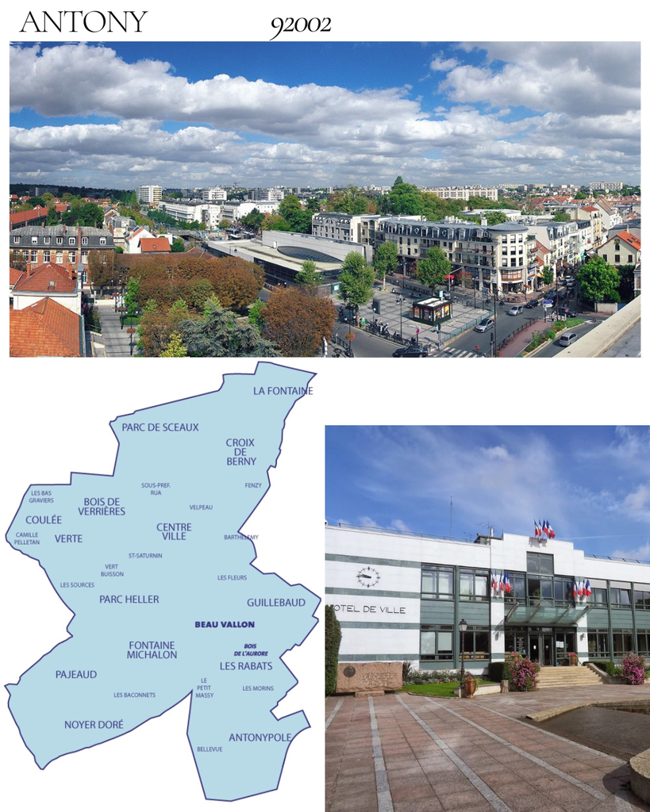

**Antony** est une commune du département des Hauts-de-Seine en région Île-de-France, située à environ 12 kilomètres au sud de Paris. Cette ville de plus de 60 000 habitants bénéficie d’une position stratégique dans la couronne parisienne, alliant les avantages de la proximité avec la capitale et la qualité de vie d’une ville à dimension humaine.

La commune se caractérise par un cadre de vie agréable, marqué par d’importants espaces verts dont le parc de Sceaux qui s’étend partiellement sur son territoire. Son paysage urbain mêle harmonieusement quartiers résidentiels, zones commerciales et secteurs préservés, offrant une diversité de styles architecturaux qui témoignent de son riche patrimoine historique.

Antony dispose d’une desserte exceptionnelle en transports en commun, avec notamment la station de RER B qui place le centre de Paris à moins de 20 minutes. Cette accessibilité, combinée à la présence de plusieurs établissements d’enseignement supérieur et de centres de recherche, en fait un territoire dynamique attractif pour les familles et les actifs.

Le marché immobilier reflète cette attractité, avec une offre diversifiée allant des appartements en centre-ville aux maisons individuelles dans les quartiers résidentiels, répondant aux attentes d’une population aux profils variés.

## A. SITUATION GLOBALE 2017-2021

### A.1 Plus de maisons ou d’appartements

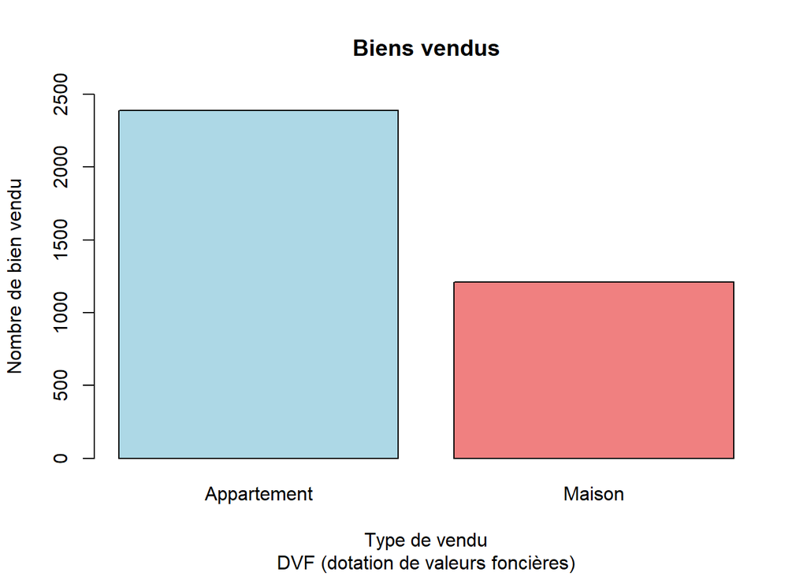

Les ventes immobilières à Antony entre 2017 et 2021 montrent une nette domination des appartements, qui représentent les deux tiers des transactions avec 2 389 ventes, contre 1 208 maisons vendues. Cette répartition confirme la prédominance de l’habitat collectif dans le parc immobilier de la commune, reflétant le caractère urbain et dense du marché antonien.

### A.2 : Prix au m2 sur l’ensemble de la période

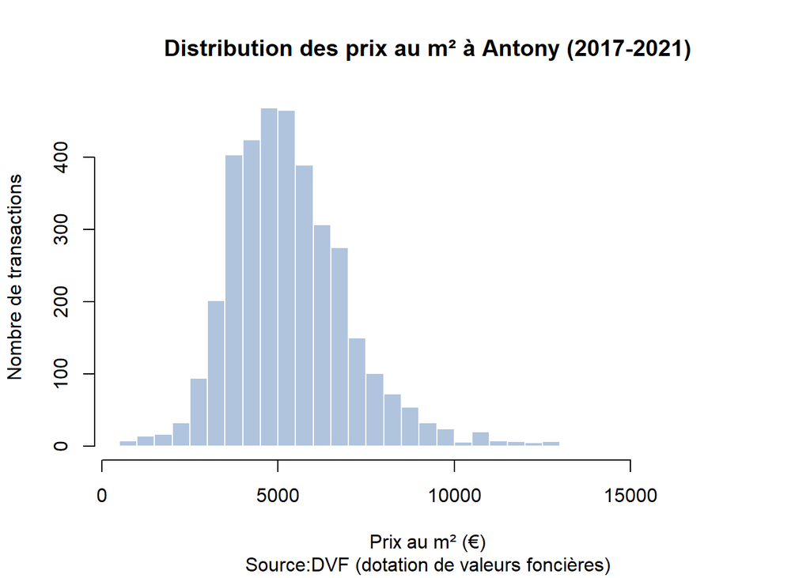

L’analyse des prix au mètre carré sur la période 2017-2021 révèle que la moitié des biens immobiliers à Antony se vend à plus de 5 160 €/m². Les prix s’échelonnent de 609 €/m² pour les biens les moins chers à 17 797 €/m² pour les plus onéreux.

La majorité des transactions se concentrent dans une fourchette comprise entre 4 175 €/m² et 6 269 €/m², avec un prix moyen de 5 364 €/m². Cette distribution témoigne d’un marché immobilier diversifié, allant de biens accessibles à des propriétés haut de gamme, tout en maintenant une valorisation médiane élevée caractéristique des communes résidentielles prisées.

- **Minimum** : 609 €/m²
- **1er quartile** : 4 175 €/m² (25% des biens en dessous de ce prix)
- **Médiane** : 5 160 €/m² (la moitié des biens en dessous de ce prix)
- **Moyenne** : 5 364 €/m²
- **3ème quartile** : 6 269 €/m² (75% des biens en dessous de ce prix)
- **Maximum** : 17 797 €/m²
- **Étendue** : 17 188 €/m²

### A.3 : Comparez le prix au m2 des maisons et des appartements

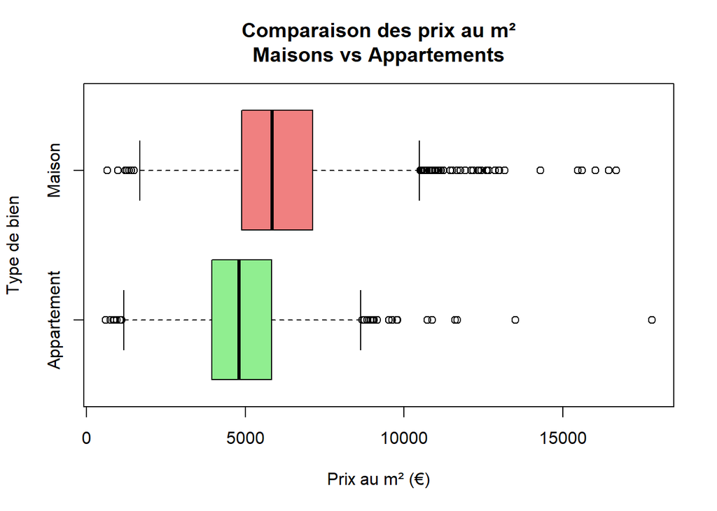

L’analyse des prix au mètre carré révèle une différence marquée entre les maisons et les appartements à Antony. La moitié des maisons se vend à plus de 5 846 €/m², tandis que la moitié des appartements se vend à plus de 4 802 €/m², soit un écart de 1 044 €/m² en faveur des maisons. Cette différence représente un supplément de 21,8% pour les maisons par rapport aux appartements.

La majorité des maisons se situent dans une fourchette de prix comprise entre 4 889 €/m² et 7 125 €/m², alors que les appartements se concentrent entre 3 954 €/m² et 5 836 €/m². En moyenne, les maisons atteignent 6 178 €/m² contre 4 953 €/m² pour les appartements, confirmant l’écart de valorisation entre les deux types de biens.

Cette disparité de prix s’explique par plusieurs facteurs structurels. Les maisons bénéficient de la valeur ajoutée des espaces extérieurs, avec jardins et terrasses qui constituent des atouts déterminants. La recherche croissante d’espaces privatifs, accentuée depuis la crise sanitaire, renforce cette tendance. Enfin, la rareté relative des maisons dans le parc immobilier communal contribue à maintenir leur prime de valorisation.

En conclusion, le marché immobilier d’Antony présente une différenciation nette entre les types de biens, les maisons bénéficiant d’une attractivité supérieure qui se traduit par une valorisation significativement plus élevée que les appartements.

### A.4 Votre commune est-elle riche ou pauvre

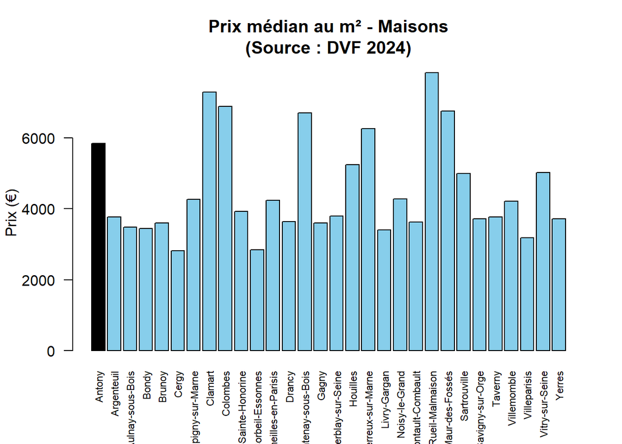

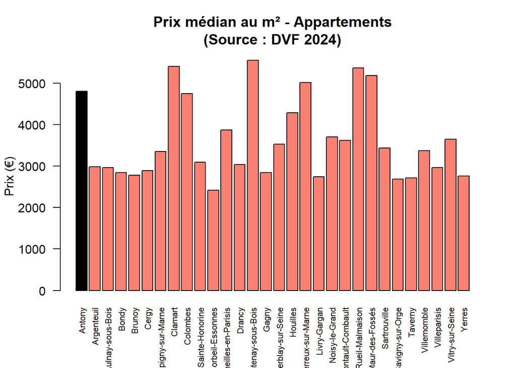

Notre analyse comparative situe Antony nettement au-dessus de la moyenne des communes du réseau Piazza Margherita. Avec un prix médian de 5 160 €/m², Antony dépasse de 31,6% la moyenne du réseau établie à 3 920 €/m², soit un écart positif de 1 240 €/m².

Cette position enviable classe Antony parmi les communes les plus riches du réseau. Ce statut suggère que la commune attire une population plutôt aisée, avec un marché davantage tourné vers des biens haut de gamme.

### A.5 Autres remarques

L’analyse du marché immobilier d’Antony révèle des caractéristiques structurelles importantes. Les maisons se distinguent nettement des appartements par leur superficie moyenne de 106 m² contre 62 m², et par leur nombre de pièces moyen de 4,6 contre 2,9. Cette différenciation explique en partie les écarts de valorisation observés entre les deux types de biens.

Par ailleurs, Antony bénéficie d’une accessibilité exceptionnelle aux transports, avec la moitié des biens situés à moins de 500 mètres d’une gare et les trois quarts à moins de 650 mètres. Cette desserte de qualité renforce l’attractivité résidentielle de la commune.

La stabilité du volume des transactions sur la période étudiée témoigne de la solidité du marché immobilier local. Ces éléments combinés - parc immobilier diversifié, excellente accessibilité et marché régulier - confirment le positionnement privilégié d’Antony dans le paysage immobilier francilien et offrent des perspectives favorables au développement de notre activité.

## B. IMPACT DE LA CRISE DU COVID EN 2020-21

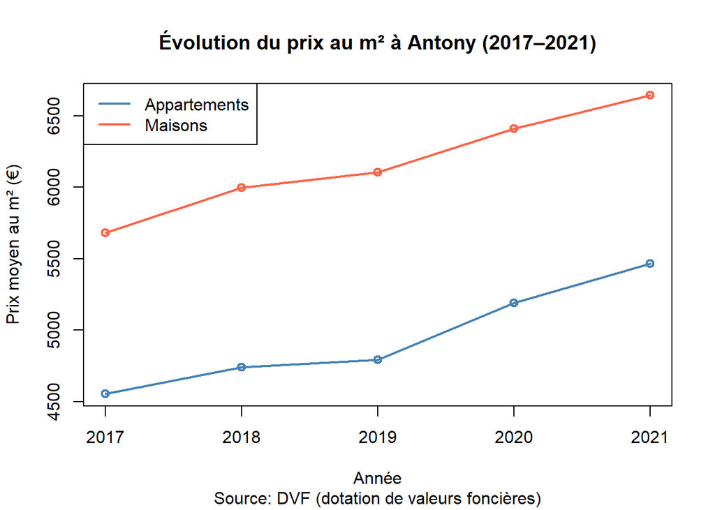

Face aux hésitations légitimes de nos clients concernant les fluctuations du marché immobilier pendant la crise COVID-19, notre analyse apporte des éléments concrets et rassurants pour éclairer leurs décisions.

**Les tendances diffèrent** sensiblement entre les deux types de biens. Les appartements ont bénéficié de la plus forte progression, tirés par l’attractivité maintenue du centre-ville et son excellente desserte en transports. Les maisons, déjà positionnées sur un segment premium, ont confirmé leur statut de produit rare avec une croissance plus modérée mais solide.

**Notre conseil** s’adapte à chaque profil. Aux vendeurs, nous confirmons que leur bien a conservé, voire accru sa valeur durant la crise. Aux acheteurs, nous soulignons qu’investir à Antony représente un choix sûr, avec un marché qui a fait ses preuves en période difficile. La croissance maintenue des prix témoigne de la confiance durable des acquéreurs dans l’avenir de la commune.

## CONCLUSION

Cette analyse approfondie du marché immobilier d’Antony témoigne de notre capacité à extraire des données brutes des enseignements stratégiques directement actionnables. Notre démarche allie rigueur méthodologique et vision opérationnelle, avec une exploitation systématique des données DVF, des traitements statistiques adaptés et une segmentation fine permettant de révéler les dynamiques cachées du marché.

Notre analyse a mis en lumière la structure duale du marché antonien, marquée par une dominance quantitative des appartements mais une valorisation supérieure des maisons, confirmant le statut résidentiel premium de la commune

La mesure précise de l’impact de la crise COVID a permis d’établir la résilience exceptionnelle du marché, avec des progressions de 14,3% pour les appartements et 8,5% pour les maisons entre 2019 et 2021

Le positionnement comparatif place Antony nettement au-dessus de la moyenne du réseau, avec un écart de valorisation de +31,6% qui en fait un marché stratégique pour l’agence

Je souhaite rester à la tête de l’agence d’Antony, considérant que cette commune représente un gisement de valeur exceptionnel pour notre développement. Plusieurs éléments fondent cette décision :

La solidité démontrée du marché pendant la crise sanitaire conforte son statut de valeur refuge dans le paysage immobilier francilien

La croissance soutenue et la demande constante offrent des perspectives de développement optimales pour notre agence

La clientèle aisée et exigeante représente un terrain d’excellence pour déployer notre expertise en conseil immobilier de haut de gamme

Cette analyse démontre notre maîtrise des outils statistiques et notre capacité à traduire des données complexes en stratégies commerciales performantes. Notre valeur ajoutée réside dans cette double compétence, technique et opérationnelle, qui nous permet de piloter la performance avec une vision éclairée par la data.

Antony constitue le terrain d’exercice idéal pour mettre en œuvre l’ensemble des compétences démontrées dans ce rapport. J’entends y développer une approche innovante du conseil immobilier, fondée sur l’analyse data et tournée vers l’excellence du service client, faisant de notre agence la référence incontournable sur ce territoire d’exception.